# Proyecto

Javier

24 de septiembre de 2015

First we download the two datasets. To do this, a function is created using the OOP method:

```r
downdata <- function(url, nastrings) {
    temp <- tempfile()
    download.file(url, temp, method = "libcurl")
    data <- read.csv(temp, na.strings = nastrings)
    unlink(temp)
    return(data)
}

trainurl <- "https://d396qusza40orc.cloudfront.net/predmachlearn/pml-training.csv"
train <- downdata(trainurl, c("", "NA", "#DIV/0!"))
testurl <- "https://d396qusza40orc.cloudfront.net/predmachlearn/pml-testing.csv"
test <- downdata(testurl, c("", "NA", "#DIV/0!"))
```

The following function selects the variables that have a different value to NAS:

Now a function is created to remove entire NA columns,and apply it to both datasets. Then we make a function that removes any variables with missing NAs. The complete function you select the variables that contain no NA:

```r
 complete <- function(x) {x[,sapply(x, function(y) !any(is.na(y)))] }
```

```r
incompl        <- function(x) {names( x[,sapply(x, function(y) any(is.na(y)))] ) }

train.na.var    <- incompl(train)
test.na.var    <- incompl(test)

train <- complete(train)
test <- complete(test)
```

We eliminate the first 7 train dataset variables:

```r
train<-train[,-c(1:7)]
test<-test[,-c(1:7)]
```

```r
library(caret)
library(randomForest)
set.seed(6633)

gbmTrain <- train(classe ~ ., data = train,method = "gbm", trControl = trainControl(method = "cv"))
set.seed(6633)

rfTrain <- train(classe ~ ., data = train, method = "rf", tuneGrid=data.frame(mtry=3), trControl = trainControl(method = "cv"))
```

Now we compare the results from the predition with the actual data:

```r
gbmTraining <- predict(gbmTrain, train)

print(confusionMatrix(gbmTraining, train$classe))
```

```
## Confusion Matrix and Statistics
##
##           Reference
## Prediction    A    B    C    D    E
##          A 5530   87    0    1    0
##          B   33 3635   72    7   22
##          C   11   74 3311   91   22
##          D    2    1   33 3105   31
##          E    4    0    6   12 3532
##
## Overall Statistics
##
##                Accuracy : 0.9741
##                  95% CI : (0.9717, 0.9762)
##     No Information Rate : 0.2844
##     P-Value [Acc > NIR] : < 2.2e-16
##
##                   Kappa : 0.9672
##  Mcnemar's Test P-Value : < 2.2e-16
##
## Statistics by Class:
##
##                      Class: A Class: B Class: C Class: D Class: E
## Sensitivity            0.9910   0.9573   0.9676   0.9655   0.9792
## Specificity            0.9937   0.9915   0.9878   0.9959   0.9986
## Pos Pred Value         0.9843   0.9644   0.9436   0.9789   0.9938
## Neg Pred Value         0.9964   0.9898   0.9931   0.9933   0.9953
## Prevalence             0.2844   0.1935   0.1744   0.1639   0.1838
## Detection Rate         0.2818   0.1853   0.1687   0.1582   0.1800
## Detection Prevalence   0.2863   0.1921   0.1788   0.1617   0.1811
## Balanced Accuracy      0.9924   0.9744   0.9777   0.9807   0.9889
```

```r
rfTraining <- predict(rfTrain, train)

print(confusionMatrix(rfTraining, train$classe))
```

```
## Confusion Matrix and Statistics
##
##           Reference
## Prediction    A    B    C    D    E
##          A 5580    0    0    0    0
##          B    0 3797    0    0    0
##          C    0    0 3422    0    0
##          D    0    0    0 3216    0
##          E    0    0    0    0 3607
##
## Overall Statistics
##
##                Accuracy : 1
##                  95% CI : (0.9998, 1)
##     No Information Rate : 0.2844
##     P-Value [Acc > NIR] : < 2.2e-16
##
##                   Kappa : 1
##  Mcnemar's Test P-Value : NA
##
## Statistics by Class:
##
##                      Class: A Class: B Class: C Class: D Class: E
## Sensitivity            1.0000   1.0000   1.0000   1.0000   1.0000
## Specificity            1.0000   1.0000   1.0000   1.0000   1.0000
## Pos Pred Value         1.0000   1.0000   1.0000   1.0000   1.0000
## Neg Pred Value         1.0000   1.0000   1.0000   1.0000   1.0000
## Prevalence             0.2844   0.1935   0.1744   0.1639   0.1838
## Detection Rate         0.2844   0.1935   0.1744   0.1639   0.1838
## Detection Prevalence   0.2844   0.1935   0.1744   0.1639   0.1838
## Balanced Accuracy      1.0000   1.0000   1.0000   1.0000   1.0000
```

With the model applied through the random forest method it was obtained more accurate prediction:

Method RF -> Accuracy : 1

Finally, we see the variable predicted values of the test dataset:

```r
  rfTraining1 <- predict(rfTrain, test)

  rfTraining1
```

```
##  [1] B A B A A E D B A A B C B A E E A B B B
## Levels: A B C D E
```

```r
  answers <- rfTraining1

  pml_write_files = function(x){
    n = length(x)
    for(i in 1:n){
     filename = paste0("problem_id_",i,".txt")
     write.table(x[i],file=filename,quote=FALSE,row.names=FALSE,col.names=FALSE)
    }
  }

 pml_write_files(answers)

 answers
```

```
##  [1] B A B A A E D B A A B C B A E E A B B B
## Levels: A B C D E
```

answers

[1] B A B A A E D B A A B C B A E E A B B B

Levels: A B C D E

Dotchart of variable importance as measured by a Random Forest:

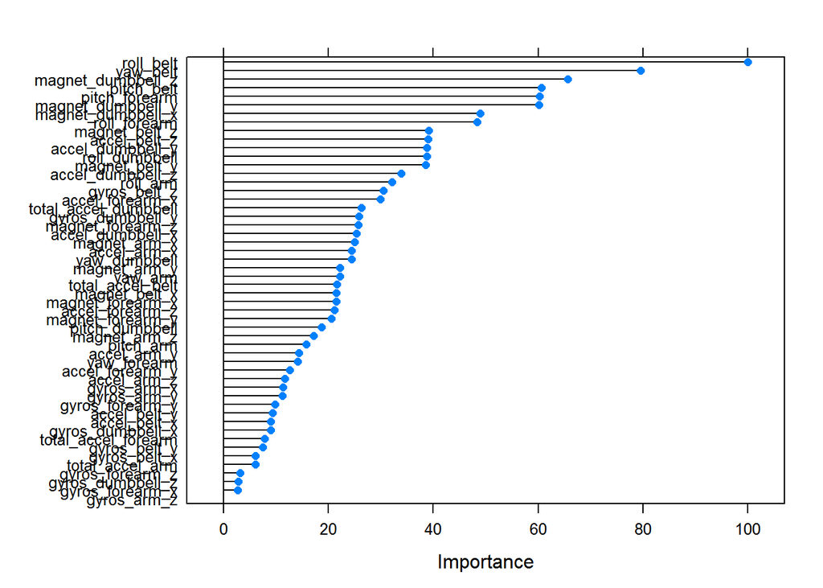

```r
plot( varImp(rfTrain) )
```